# Chapter 6 - Longitudinal data

```r
date()
```

```
## [1] "Mon Dec 13 02:11:58 2021"
```

```r
knitr::opts_chunk$set(fig.width=12, fig.height=8)
```

## RATS

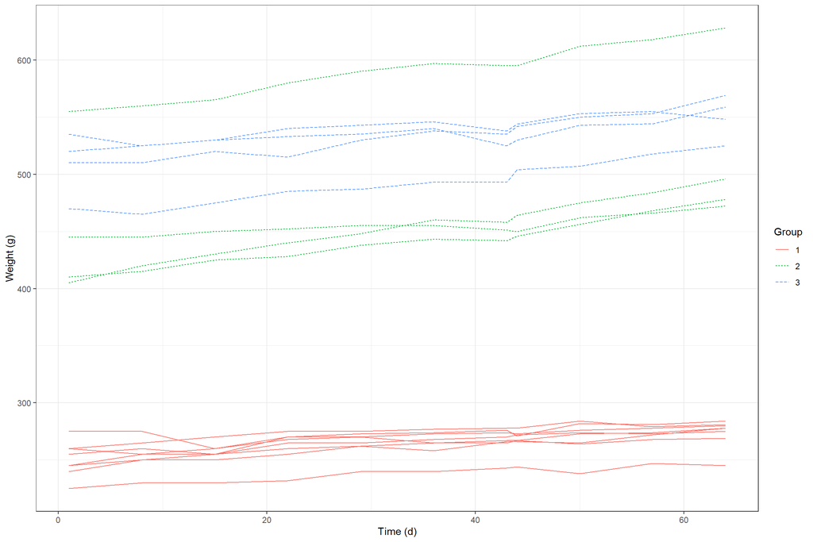

```r
library(ggplot2)
library(dplyr)
library(tidyr)

### Reading the wrangled longidutal RATS data
RATSL<-read.table('data/RATSL.txt', header = T, sep = '\t')

### Reading also the original RATS data for later use
RATS<-read.table('https://raw.githubusercontent.com/KimmoVehkalahti/MABS/master/Examples/data/rats.txt', header = T, sep = '\t')

### Setting ID and Group as factor
RATSL$ID <- factor(RATSL$ID)
RATSL$Group <- factor(RATSL$Group)


### Plotting the RATS dataset
ggplot(RATSL, aes(x = Time, y = Weight, group = ID, col = Group)) +
  geom_line(aes(linetype = Group)) +
  scale_x_continuous(name = "Time (d)") +
  scale_y_continuous(name = "Weight (g)") + theme_bw()
```

### Individual response profiles by group before and after standardization

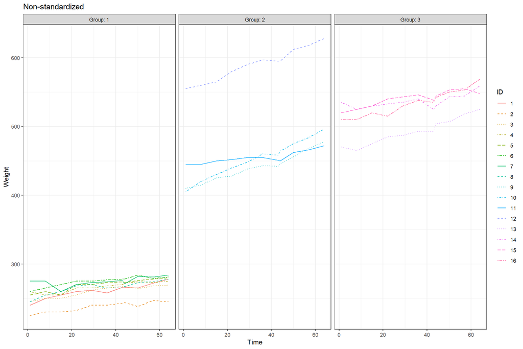

```r
### Plotting individual response profiles by group for RATSL

ggplot(RATSL, aes(x = Time, y = Weight,  col = ID, linetype = ID)) +
  geom_line() +
  scale_linetype_manual(values = rep(1:10, times=11)) +
  facet_grid(. ~ Group, labeller = label_both) +
  theme(legend.position = "none") +
  ggtitle("Non-standardized") +
  scale_y_continuous(limits = c(min(RATSL$Weight), max(RATSL$Weight))) + theme_bw()
```

```r
### Number rats in group
n <- 11
# Summary data with mean
RATSS <- RATSL %>%
  group_by(Time) %>%
  mutate(Weight_std = (Weight - mean(Weight))/sd(Weight)) %>%
  ungroup()


glimpse(RATSS)
```

```
## Rows: 176
## Columns: 6
## $ ID         <fct> 1, 2, 3, 4, 5, 6, 7, 8, 9, 10, 11, 12, 13, 14, 15, 16, 1, 2~
## $ Group      <fct> 1, 1, 1, 1, 1, 1, 1, 1, 2, 2, 2, 2, 3, 3, 3, 3, 1, 1, 1, 1,~
## $ WD         <chr> "WD1", "WD1", "WD1", "WD1", "WD1", "WD1", "WD1", "WD1", "WD~
## $ Weight     <int> 240, 225, 245, 260, 255, 260, 275, 245, 410, 405, 445, 555,~
## $ Time       <int> 1, 1, 1, 1, 1, 1, 1, 1, 1, 1, 1, 1, 1, 1, 1, 1, 8, 8, 8, 8,~
## $ Weight_std <dbl> -1.0011429, -1.1203857, -0.9613953, -0.8421525, -0.8819001,~
```

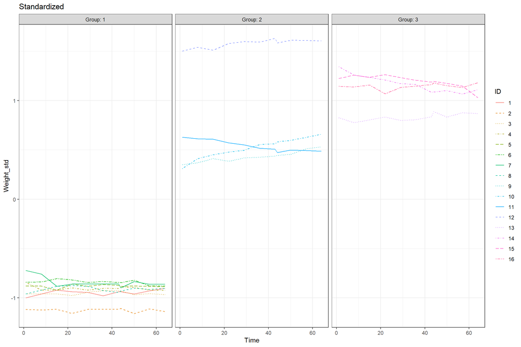

```r
# Plot the mean profiles
ggplot(RATSS, aes(x = Time, y = Weight_std, col = ID, linetype = ID)) +
  geom_line() +
  scale_linetype_manual(values = rep(1:10, times=11)) +
  facet_grid(. ~ Group, labeller = label_both) +
  theme(legend.position = "none") +
  ggtitle("Standardized") +
  scale_y_continuous(limits = c(min(RATSS$Weight_std), max(RATSS$Weight_std))) + theme_bw()
```

Plots show that that removed the trend of increasing weight over time, but the group differences remain.

### Summary measure statistics

Here I try to see the trend of groups, by plottin mean profiles for each treatment group, along within group indication of the variation ( standard error of mean) of the observations at each time point.

```r
### using the n() function from dplyr to get group size
RATSS <- RATSL %>%
  group_by(Group, Time) %>%
  summarise(mean = mean(Weight), se = sd(Weight) /  sqrt(n())) %>%
  ungroup()
### Glimpse at the data
glimpse(RATSS)
```

```
## Rows: 33
## Columns: 4
## $ Group <fct> 1, 1, 1, 1, 1, 1, 1, 1, 1, 1, 1, 2, 2, 2, 2, 2, 2, 2, 2, 2, 2, 2~
## $ Time  <int> 1, 8, 15, 22, 29, 36, 43, 44, 50, 57, 64, 1, 8, 15, 22, 29, 36, ~
## $ mean  <dbl> 250.625, 255.000, 254.375, 261.875, 264.625, 265.000, 267.375, 2~
## $ se    <dbl> 5.381640, 4.629100, 4.057346, 4.808614, 3.909409, 4.166190, 3.87~
```

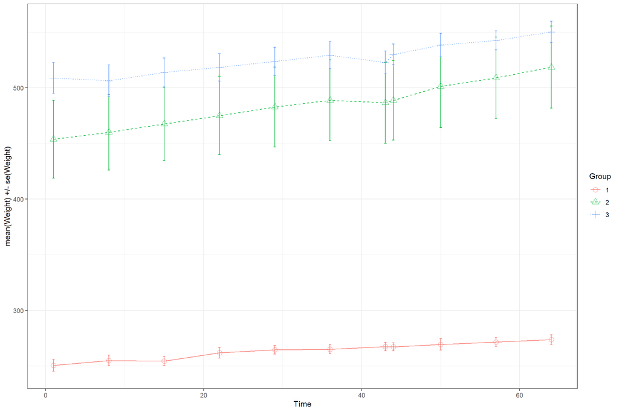

```r
### Line plot for groups
ggplot(RATSS, aes(x = Time, y = mean, linetype = Group, col = Group, shape = Group)) +
  geom_line() +
  scale_linetype_manual(values = c(1,2,3)) +
  geom_point(size=3) +
  scale_shape_manual(values = c(1,2,3)) +
  geom_errorbar(aes(ymin = mean - se, ymax = mean + se, linetype="1"), width=0.3) +
  theme(legend.position = c(0.8,0.8)) +
  scale_y_continuous(name = "mean(Weight) +/- se(Weight)") + theme_bw()
```

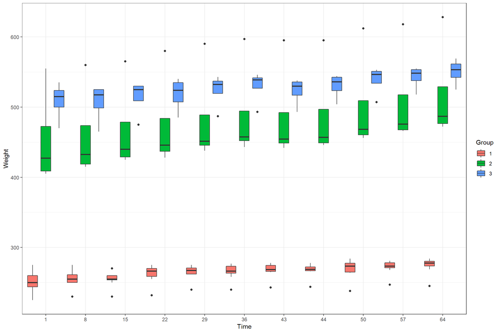

```r
### Box plot for groups
ggplot(RATSL, aes(x = factor(Time), y = Weight, fill = Group)) +
  geom_boxplot(position = position_dodge(width = 1)) +
  scale_x_discrete(name = "Time") + theme_bw()
```

Here I observe again that weight is much heavier on groups 2 and 3 compared to 1. Weight also increases more on 2 and 3 over time, and variability is higher.

### Outliers

Here I check whether there are significant outliers in the dataset

```r
RATSL8S <- RATSL %>%
  filter(Time >= 1) %>%
  group_by(Group, ID) %>%
  summarise( mean=mean(Weight) ) %>%
  ungroup()
```

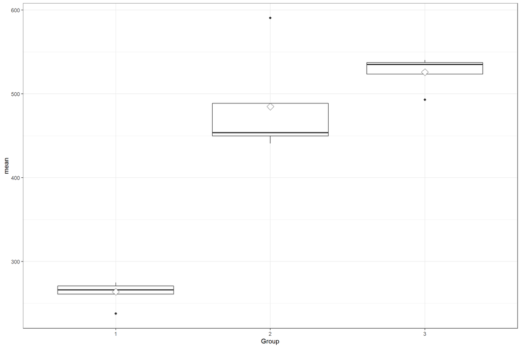

```r
ggplot(RATSL8S, aes(x = Group, y = mean)) +
  geom_boxplot() + stat_summary(fun = "mean", geom = "point", shape=23, size=4, fill = "white") + theme_bw()
```

I can see that there’s a quite significant outlier at group 2, Outliers at 1 and 3 doesn’t seem that large deviations. Let’s remove group 2’s outlier and plot again:

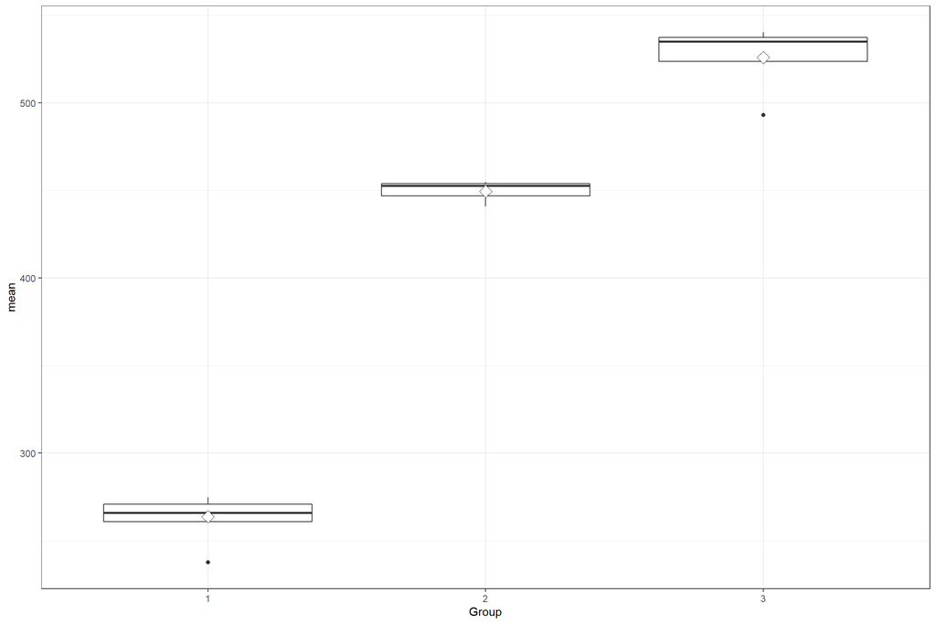

```r
### Remove the outlier from group 2:
RATSL8S1 <- RATSL8S %>%
  filter(mean < 550)


ggplot(RATSL8S1, aes(x = Group, y = mean)) +
  geom_boxplot() + stat_summary(fun = "mean", geom = "point", shape=23, size=4, fill = "white") + theme_bw()
```

No outliers at group 2 anymore!

### ANOVA

Here, I perform ANOVA to observe if graphically observed differences between groups are also statistically significant, by setting Group 1 as baseline.

```r
### Adding baseline values to the summary data
RATSL8S2 <- RATSL8S %>%
  mutate(baseline = RATS$WD1)

### Fitting ANCOVA model
fit <- lm(mean ~ baseline + Group, data = RATSL8S2)

### Summary
summary(fit)
```

```
##
## Call:
## lm(formula = mean ~ baseline + Group, data = RATSL8S2)
##
## Residuals:
##     Min      1Q  Median      3Q     Max
## -21.732  -3.812   1.991   6.889  13.455
##
## Coefficients:
##             Estimate Std. Error t value Pr(>|t|)
## (Intercept) 30.14886   19.88779   1.516   0.1554
## baseline     0.93194    0.07793  11.959 5.02e-08 ***
## Group2      31.68866   17.11189   1.852   0.0888 .
## Group3      21.52296   21.13931   1.018   0.3287
## ---
## Signif. codes:  0 '***' 0.001 '**' 0.01 '*' 0.05 '.' 0.1 ' ' 1
##
## Residual standard error: 10.62 on 12 degrees of freedom
## Multiple R-squared:  0.9947, Adjusted R-squared:  0.9933
## F-statistic: 747.8 on 3 and 12 DF,  p-value: 6.636e-14
```

```r
### Anova
anova(fit)
```

```
## Analysis of Variance Table
##
## Response: mean
##           Df Sum Sq Mean Sq   F value    Pr(>F)
## baseline   1 252125  252125 2237.0655 5.217e-15 ***
## Group      2    726     363    3.2219   0.07586 .
## Residuals 12   1352     113
## ---
## Signif. codes:  0 '***' 0.001 '**' 0.01 '*' 0.05 '.' 0.1 ' ' 1
```

## BPRS

In BPRS dataset “40 male subjects were randomly assigned to one of two treatment groups and each subject was rated on the brief psychiatric rating scale (BPRS) measured before treatment began (week 0) and then at weekly intervals for eight weeks. The BPRS assesses the level of 18 symptom constructs such as hostility, suspiciousness, hallucinations and grandiosity; each of these is rated from one (not present) to seven (extremely severe). The scale is used to evaluate patients suspected of having schizophrenia.” Page 5: https://mooc.helsinki.fi/pluginfile.php/192850/course/section/7335/MABS4IODS-Part6.pdf

```r
### BPRS
library("lme4")
library(gridExtra)
```

```r
library(grid)

### Reading the longidutal BPRS data, which was created in the Wrangling exercise
BPRSL<- read.table('data/BPRSL.txt', header = T, sep = '\t')

### Reading also original BPRS data for some plot
BPRS<-read.table('https://raw.githubusercontent.com/KimmoVehkalahti/MABS/master/Examples/data/BPRS.txt', header = T, sep = ' ')


### Assigning treatment and subject as factors
BPRSL$treatment <- factor(BPRSL$treatment)
BPRSL$subject <- factor(BPRSL$subject)

### Creating unique id variable for individuals as per suggestion on forum
# BPRS$id <- seq.int(nrow(BPRS))

glimpse(BPRSL)
```

```
## Rows: 360
## Columns: 6
## $ treatment <fct> 1, 1, 1, 1, 1, 1, 1, 1, 1, 1, 1, 1, 1, 1, 1, 1, 1, 1, 1, 1, ~
## $ subject   <fct> 1, 2, 3, 4, 5, 6, 7, 8, 9, 10, 11, 12, 13, 14, 15, 16, 17, 1~
## $ id        <int> 1, 2, 3, 4, 5, 6, 7, 8, 9, 10, 11, 12, 13, 14, 15, 16, 17, 1~
## $ weeks     <chr> "week0", "week0", "week0", "week0", "week0", "week0", "week0~
## $ bprs      <int> 42, 58, 54, 55, 72, 48, 71, 30, 41, 57, 30, 55, 36, 38, 66, ~
## $ week      <int> 0, 0, 0, 0, 0, 0, 0, 0, 0, 0, 0, 0, 0, 0, 0, 0, 0, 0, 0, 0, ~
```

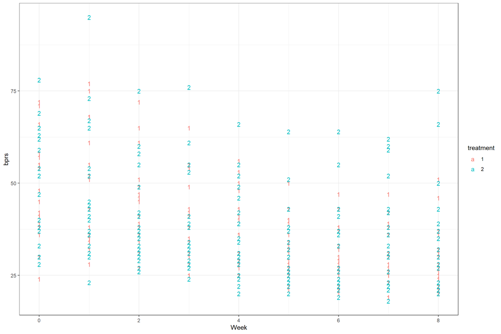

```r
ggplot(BPRSL, aes(x = week, y = bprs, group = subject, col = treatment)) +
  geom_text(aes(label = treatment)) +
  scale_x_continuous(name = "Week") +
  scale_y_continuous(name = "bprs") + theme_bw()
```

### bprs standardization

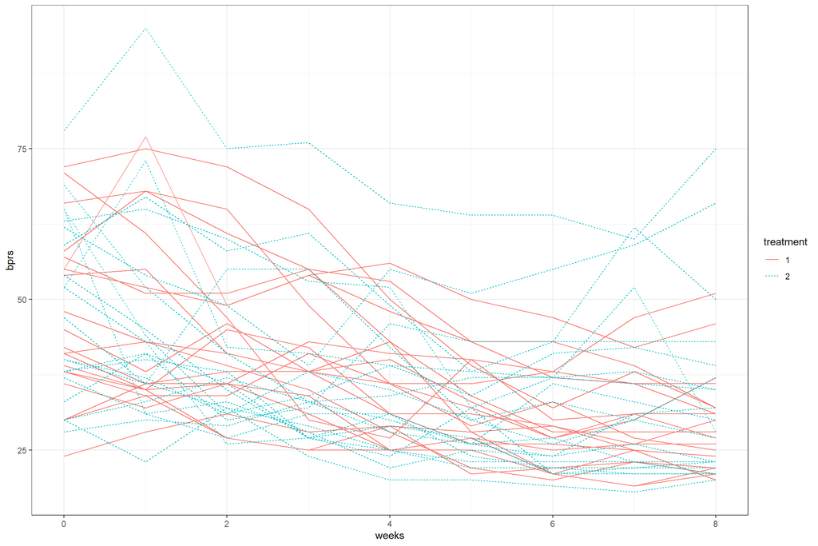

```r
ggplot(BPRSL, aes(x = week, y = bprs, group = id, col = treatment)) +
  geom_line(aes(linetype = treatment)) +
  scale_x_continuous(name = "weeks") +
  scale_y_continuous(name = "bprs") +
  theme(legend.position = "top") + theme_bw()
```

```r
### Standardising bprs
BPRSL <- BPRSL %>%
  group_by(week) %>%
  mutate(stdbprs = (bprs - mean(bprs))/sd(bprs) ) %>%
  ungroup()

glimpse(BPRSL)
```

```
## Rows: 360
## Columns: 7
## $ treatment <fct> 1, 1, 1, 1, 1, 1, 1, 1, 1, 1, 1, 1, 1, 1, 1, 1, 1, 1, 1, 1, ~
## $ subject   <fct> 1, 2, 3, 4, 5, 6, 7, 8, 9, 10, 11, 12, 13, 14, 15, 16, 17, 1~
## $ id        <int> 1, 2, 3, 4, 5, 6, 7, 8, 9, 10, 11, 12, 13, 14, 15, 16, 17, 1~
## $ weeks     <chr> "week0", "week0", "week0", "week0", "week0", "week0", "week0~
## $ bprs      <int> 42, 58, 54, 55, 72, 48, 71, 30, 41, 57, 30, 55, 36, 38, 66, ~
## $ week      <int> 0, 0, 0, 0, 0, 0, 0, 0, 0, 0, 0, 0, 0, 0, 0, 0, 0, 0, 0, 0, ~
## $ stdbprs   <dbl> -0.4245908, 0.7076513, 0.4245908, 0.4953559, 1.6983632, 0.00~
```

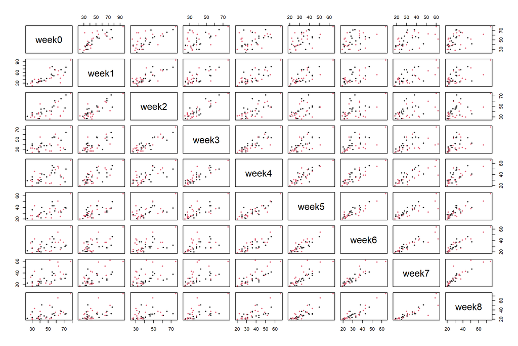

```r
pairs(BPRS[, 3:11], cex = 0.5, col = BPRS$treatment)
```

### The Linear model

Here I implement a basic linear model for the data.

```r
### create a regression model BPRSL_reg
BPRSL_reg <- lm(bprs ~ week + treatment, data = BPRSL)

### print out a summary of the model
summary(BPRSL_reg)
```

```
##
## Call:
## lm(formula = bprs ~ week + treatment, data = BPRSL)
##
## Residuals:
##     Min      1Q  Median      3Q     Max
## -22.454  -8.965  -3.196   7.002  50.244
##
## Coefficients:
##             Estimate Std. Error t value Pr(>|t|)
## (Intercept)  46.4539     1.3670  33.982   <2e-16 ***
## week         -2.2704     0.2524  -8.995   <2e-16 ***
## treatment2    0.5722     1.3034   0.439    0.661
## ---
## Signif. codes:  0 '***' 0.001 '**' 0.01 '*' 0.05 '.' 0.1 ' ' 1
##
## Residual standard error: 12.37 on 357 degrees of freedom
## Multiple R-squared:  0.1851, Adjusted R-squared:  0.1806
## F-statistic: 40.55 on 2 and 357 DF,  p-value: < 2.2e-16
```

Altogether, the model explains 18,06% of bprs variance. Summary shows that measure time “week” is statistically significant (P<2e-16) in explaining bprs, whereas treatment is not. However, linear model isn’t (P=0.661). However, it should be noted that model assumes repeated measurements aren’t related, which isn’t true here.

### Fitting Random Intercept Model to to BPRS dataset, treatment and week are explanatory variables

```r
### Create a random intercept model
BPRSL_ref <- lmer(bprs ~ week + treatment + (1 | id), data = BPRSL, REML = FALSE)

### Print the summary of the model
summary(BPRSL_ref)
```

```
## Linear mixed model fit by maximum likelihood  ['lmerMod']
## Formula: bprs ~ week + treatment + (1 | id)
##    Data: BPRSL
##
##      AIC      BIC   logLik deviance df.resid
##   2582.9   2602.3  -1286.5   2572.9      355
##
## Scaled residuals:
##      Min       1Q   Median       3Q      Max
## -2.27506 -0.59909 -0.06104  0.44226  3.15835
##
## Random effects:
##  Groups   Name        Variance Std.Dev.
##  id       (Intercept) 97.39    9.869
##  Residual             54.23    7.364
## Number of obs: 360, groups:  id, 40
##
## Fixed effects:
##             Estimate Std. Error t value
## (Intercept)  46.4539     2.3521  19.750
## week         -2.2704     0.1503 -15.104
## treatment2    0.5722     3.2159   0.178
##
## Correlation of Fixed Effects:
##            (Intr) week
## week       -0.256
## treatment2 -0.684  0.000
```

```r
### ref1
BPRS_ref1 <- lmer(bprs ~ week + treatment + (week | id), data = BPRSL, REML = FALSE)


### print a summary of the model
summary(BPRS_ref1)
```

```
## Linear mixed model fit by maximum likelihood  ['lmerMod']
## Formula: bprs ~ week + treatment + (week | id)
##    Data: BPRSL
##
##      AIC      BIC   logLik deviance df.resid
##   2523.2   2550.4  -1254.6   2509.2      353
##
## Scaled residuals:
##     Min      1Q  Median      3Q     Max
## -2.4655 -0.5150 -0.0920  0.4347  3.7353
##
## Random effects:
##  Groups   Name        Variance Std.Dev. Corr
##  id       (Intercept) 167.827  12.955
##           week          2.331   1.527   -0.67
##  Residual              36.747   6.062
## Number of obs: 360, groups:  id, 40
##
## Fixed effects:
##             Estimate Std. Error t value
## (Intercept)  45.9830     2.6470  17.372
## week         -2.2704     0.2713  -8.370
## treatment2    1.5139     3.1392   0.482
##
## Correlation of Fixed Effects:
##            (Intr) week
## week       -0.545
## treatment2 -0.593  0.000
```

### Random Intercept and Random Slope Model with interaction

Here I am making Random Intercept and Random Slope Model with interaction, which group × time interaction.

```r
# create a random intercept and random slope model
BPRS_ref2 <- lmer(bprs ~ week * treatment + (week | id), data = BPRSL, REML = FALSE)

# print a summary of the model
summary(BPRS_ref2)
```

```
## Linear mixed model fit by maximum likelihood  ['lmerMod']
## Formula: bprs ~ week * treatment + (week | id)
##    Data: BPRSL
##
##      AIC      BIC   logLik deviance df.resid
##   2523.5   2554.5  -1253.7   2507.5      352
##
## Scaled residuals:
##     Min      1Q  Median      3Q     Max
## -2.4747 -0.5256 -0.0866  0.4435  3.7884
##
## Random effects:
##  Groups   Name        Variance Std.Dev. Corr
##  id       (Intercept) 164.204  12.814
##           week          2.203   1.484   -0.66
##  Residual              36.748   6.062
## Number of obs: 360, groups:  id, 40
##
## Fixed effects:
##                 Estimate Std. Error t value
## (Intercept)      47.8856     2.9840  16.047
## week             -2.6283     0.3752  -7.006
## treatment2       -2.2911     4.2200  -0.543
## week:treatment2   0.7158     0.5306   1.349
##
## Correlation of Fixed Effects:
##             (Intr) week   trtmn2
## week        -0.668
## treatment2  -0.707  0.473
## wek:trtmnt2  0.473 -0.707 -0.668
```

```r
# perform an ANOVA test on the two models
anova(BPRS_ref2, BPRS_ref1)
```

```
## Data: BPRSL
## Models:
## BPRS_ref1: bprs ~ week + treatment + (week | id)
## BPRS_ref2: bprs ~ week * treatment + (week | id)
##           npar    AIC    BIC  logLik deviance Chisq Df Pr(>Chisq)
## BPRS_ref1    7 2523.2 2550.4 -1254.6   2509.2
## BPRS_ref2    8 2523.5 2554.6 -1253.7   2507.5  1.78  1     0.1821
```

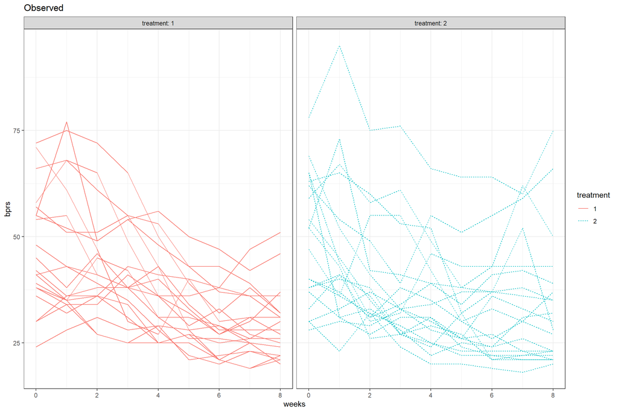

```r
# draw the plot of RATSL
ggplot(BPRSL, aes(x = week, y = bprs, group = id, col = treatment)) +
  geom_line(aes(linetype = treatment)) +
  scale_x_continuous(name = "weeks") +
  scale_y_continuous(name = "bprs") +
  ggtitle("Observed") +
  facet_grid(. ~ treatment, labeller = label_both) +
  theme(legend.position = "top") + theme_bw()
```

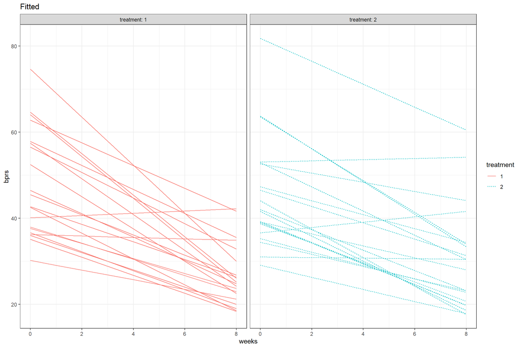

```r
# Create a vector of the fitted values
Fitted <- fitted(BPRS_ref2)

# Create a new column fitted to RATSL

BPRSL <- BPRSL %>%
  mutate(Fitted)

# draw the plot of RATSL
ggplot(BPRSL, aes(x = week, y = Fitted, group = id, col = treatment)) +
  geom_line(aes(linetype = treatment)) +
  scale_x_continuous(name = "weeks") +
  scale_y_continuous(name = "bprs") +
  ggtitle("Fitted") +
  facet_grid(. ~ treatment, labeller = label_both) +
  theme(legend.position = "top") + theme_bw()
```